# Normalized z-score for genomic association tests

Authors: Roberto Malinverni and David Corujo Gracia

## Introduction

In the R package [*regioneReloaded*](https://bioconductor.org/packages/release/bioc/html/regioneReloaded.html) we implement the use of a “normalized z-score” (nZS) as a useful parameter to reduce the z-score (ZS) value dependency on the number of regions included in the context of a permutation test using genomic regions. The nZS is defined as the ZS divided by the square root of the number of elements in a region set.

In this script, we showcase a series of examples to test and empirically demonstrate the relationship between the ZS and nZS values when performing permutation tests. First, we simplify the problem to a minimal probabilistic scenario. Then, we report the results of anlaysis run on publicly available ChIP-Seq datasets from the [ENCODE project](https://www.encodeproject.org/).

## Simulated samples

The use of the nZS was originally conceptualized and tested in the context of evaluating the number of overlaps between genomic regions, although we test its usability with other evaluation methods later in this document.

An overlap between two genomic regions can be defined by different criteria, but eventually comes down to a binary event: either two regions are considered to overlap or not. We model this probabilistic behavior by reducing the concept of region sets to numerical vectors. In essence, we can think of these numbers as coordinates on the genome and the regions reduced to single points. If the same number is present in two vectors, that represents one “overlap”.

Following this reasoning, we create 5 vectors containing a set of numbers (not replicated), all of them chosen from a “coordinate universe” of 1 to 100000 with the following rules:

**Tester** - 1000 **random** numbers chosen from our universe  
**test1** - 250 numbers: 50 **present** in Tester and 200 **random**  
**test1_bis** - 1050 numbers: 50 **present** in Tester and 1000 **random**  
**test1_ter** - 3000 numbers: 1000 **present** in Tester and 2000 **random**  
**test2** - 500 **random** numbers  
**test3** - 500 **random** numbers **not** present in Tester

**testX** samples will be associated with Tester using permutation tests to simulate divergent cases of association.

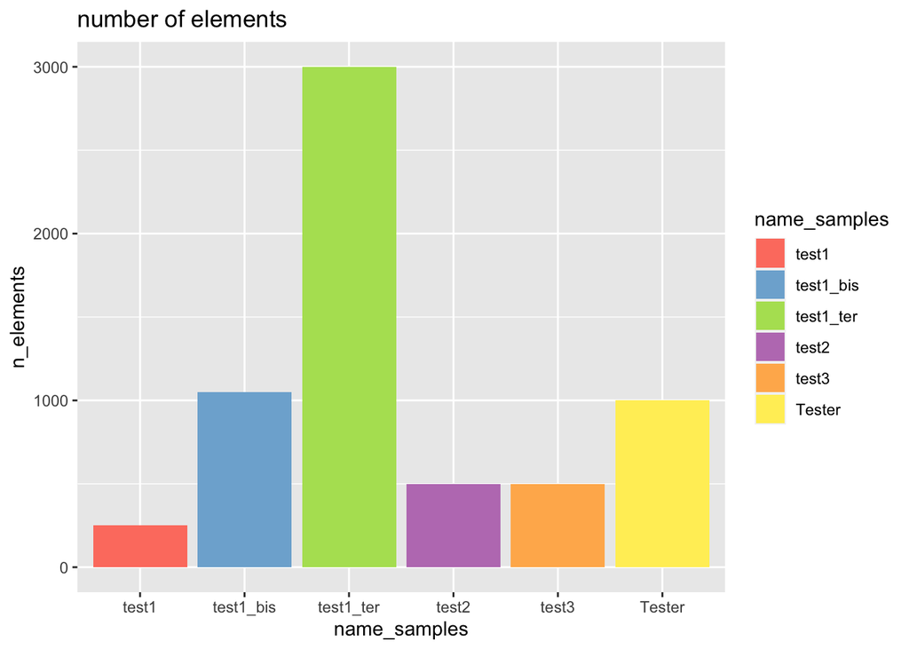

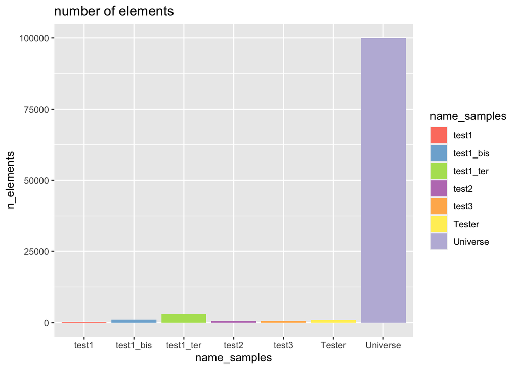

## Simple permutation test

The testing approach presented here performs a permutation test between one of the above described vectors and the Tester vector to determine if the observed “overlap” is significantly different from what we would “expect” randomly. We randomize 5000 times the query vector by sampling the same number of elements from the universe, and record each time the number of overlaps with Tester. We then take the initial observed overlap and compare it to the random distribution, obtaining a Z-score value and an associated p-value. In these examples, we will focus exclusively on the z-score and the normalized z-score.

To assess the variability of the z-score depending on the size of the query set used, we repeat the permutation test several times using increasing sub-fractions of the sample.

Below, we show the observed overlap between each vector and our Tester, as well as the ZS and nZS values obtained using a different fraction of each vector. While the absolute value of the ZS for significant associations greatly increases with bigger sample sizes, the nZS remains much more stable and in a more comparable range between different tests.

**Test1 vs Tester SimplePT**

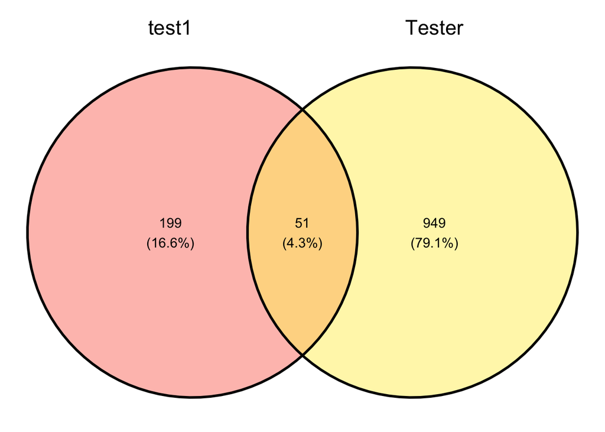

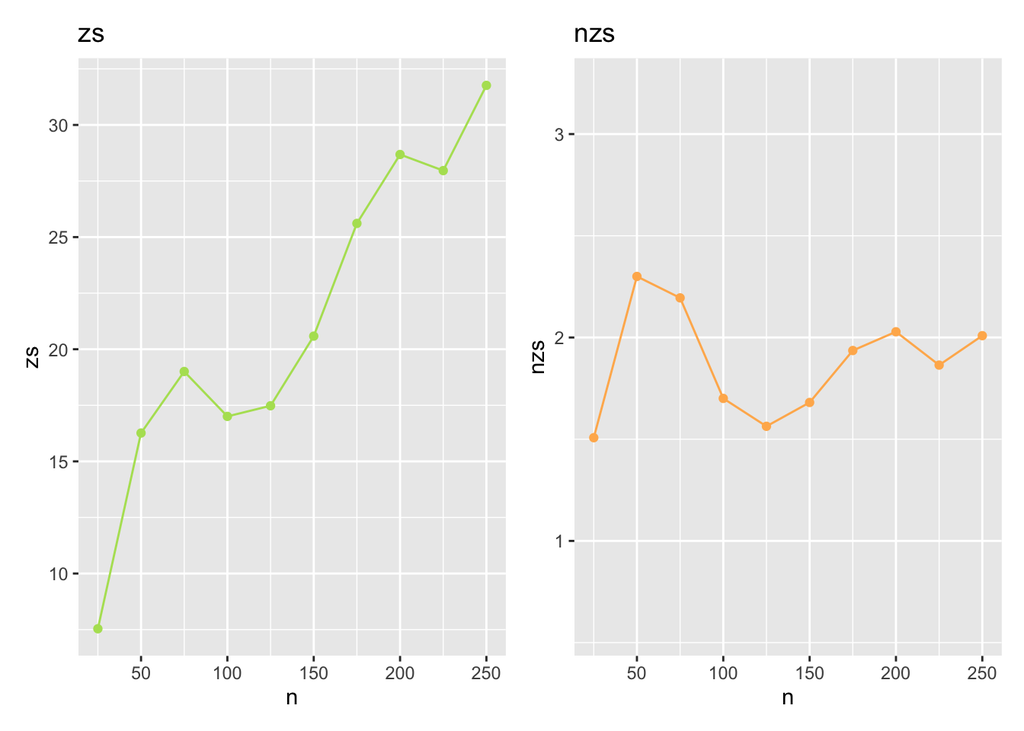

**Test1_bis vs Tester SimplePT**

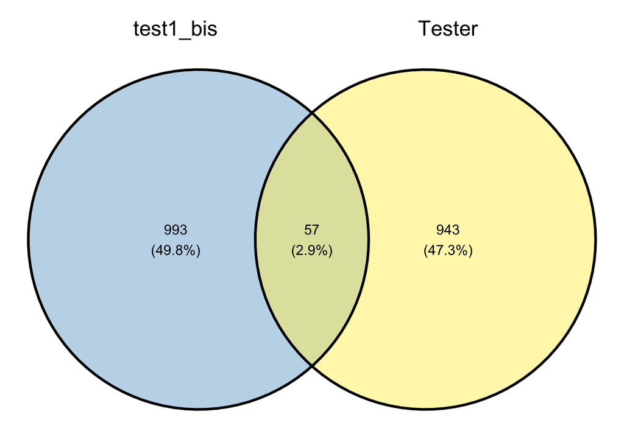

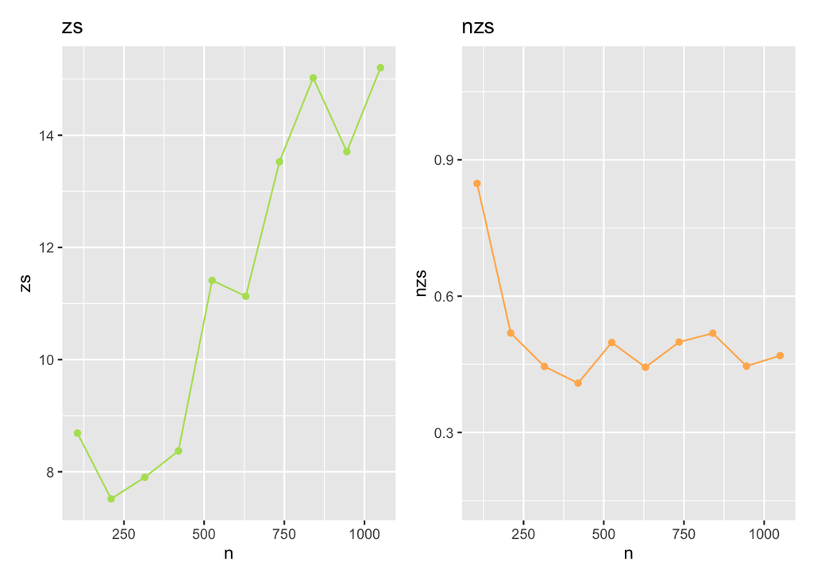

**Test1_ter vs Tester SimplePT**

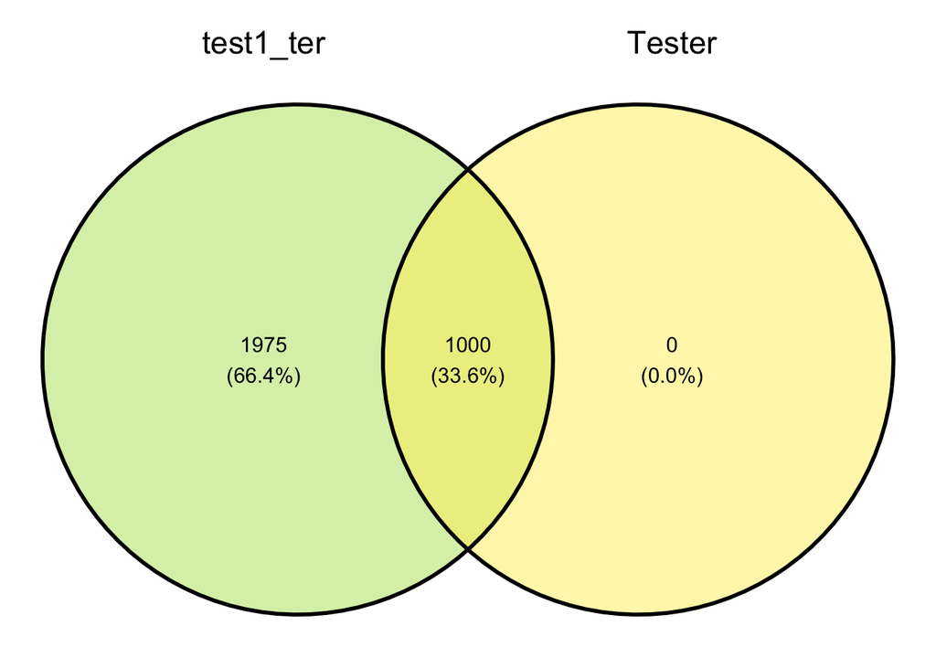

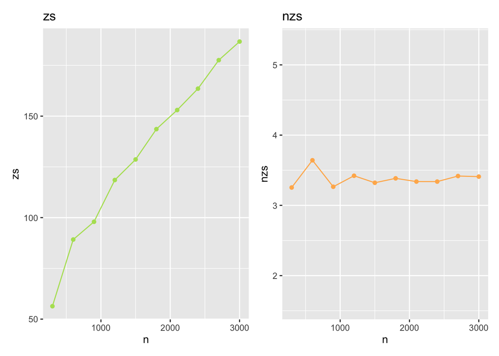

**Test2 vs Tester SimplePT**

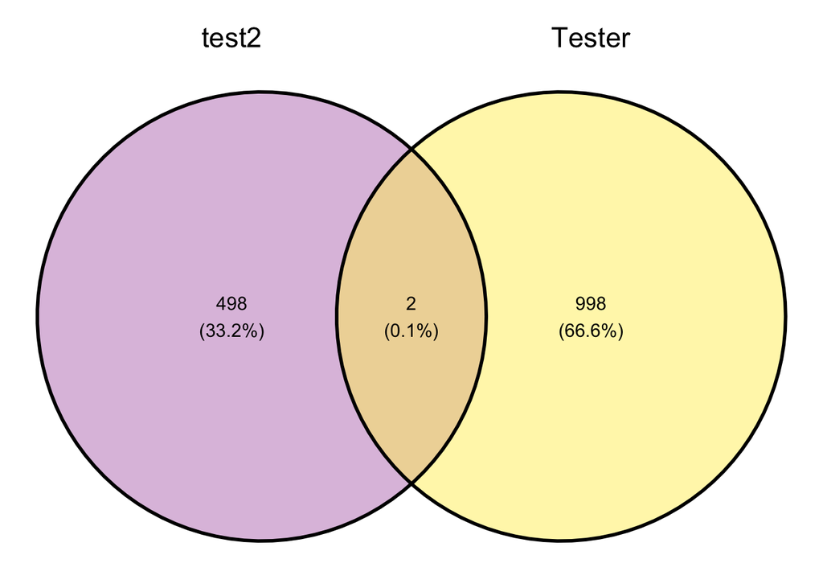

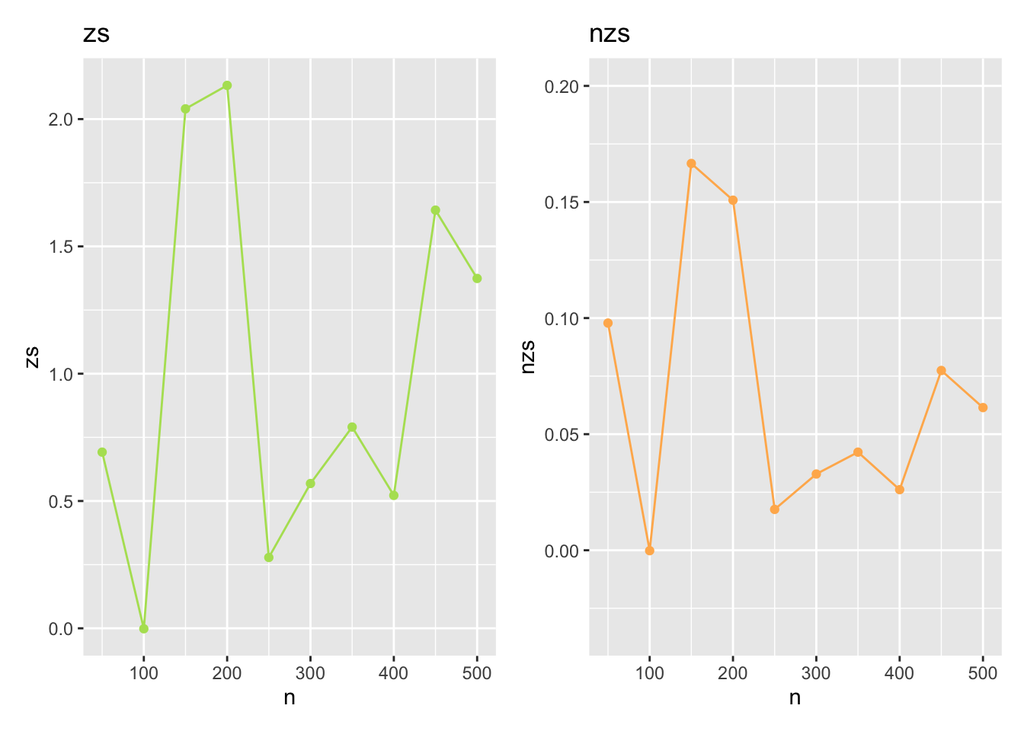

**Test3 vs Tester SimplePT**

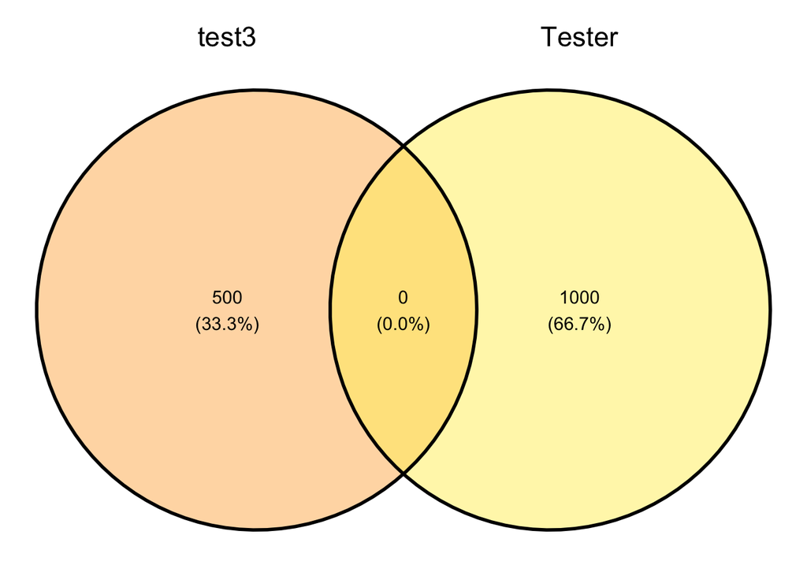

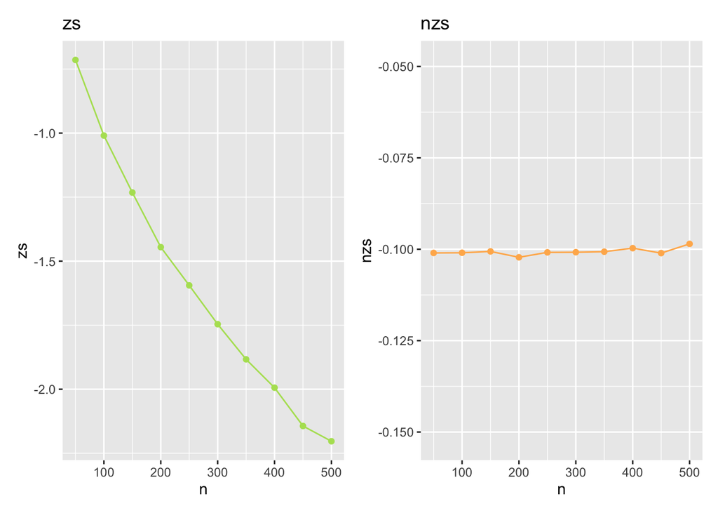

## Reproduciblity and stability of ZS and nZS values

Given the stochastic nature of the permutation test, we repeat the procedure described above 100 times for each comparison, with 5000 randomization steps each time. This approach allows us to evaluate the robustness of the results obtained in terms of obtained ZS and nZS values.

Below, boxplot representations of the 100 results obtained for each test and subfraction of the sample. We observe that results are highly reproducible and, in particular, that the nZS shows a very good stability.

**Test1 vs Tester MultiPT**

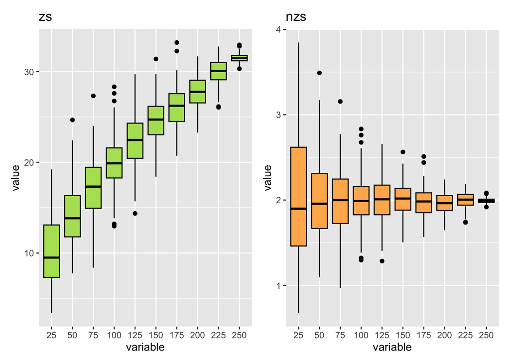

**Test1_bis vs Tester MultiPT**

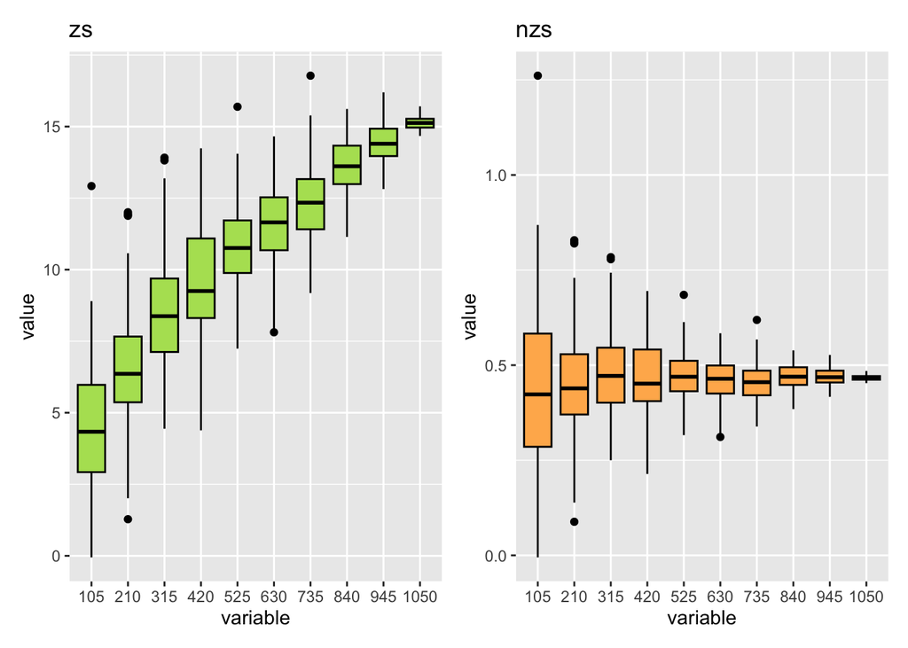

**Test1_ter vs Tester MultiPT**

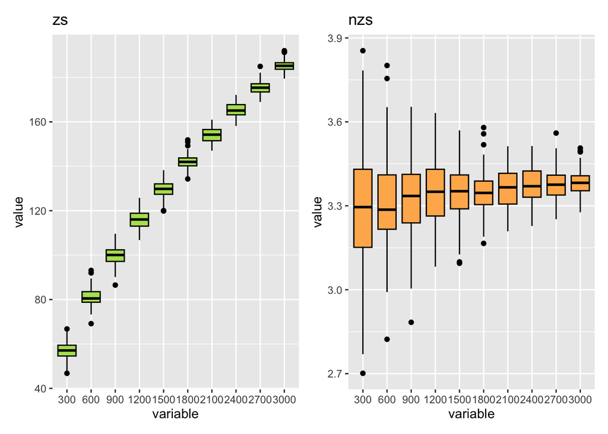

**Test2 vs Tester MultiPT**

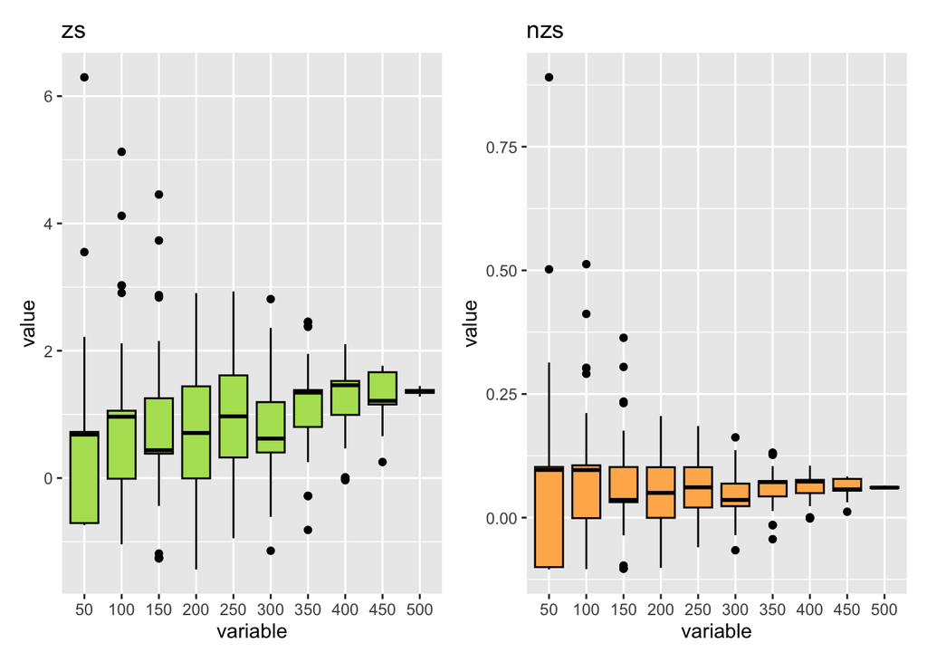

**Test3 vs Tester MultiPT**

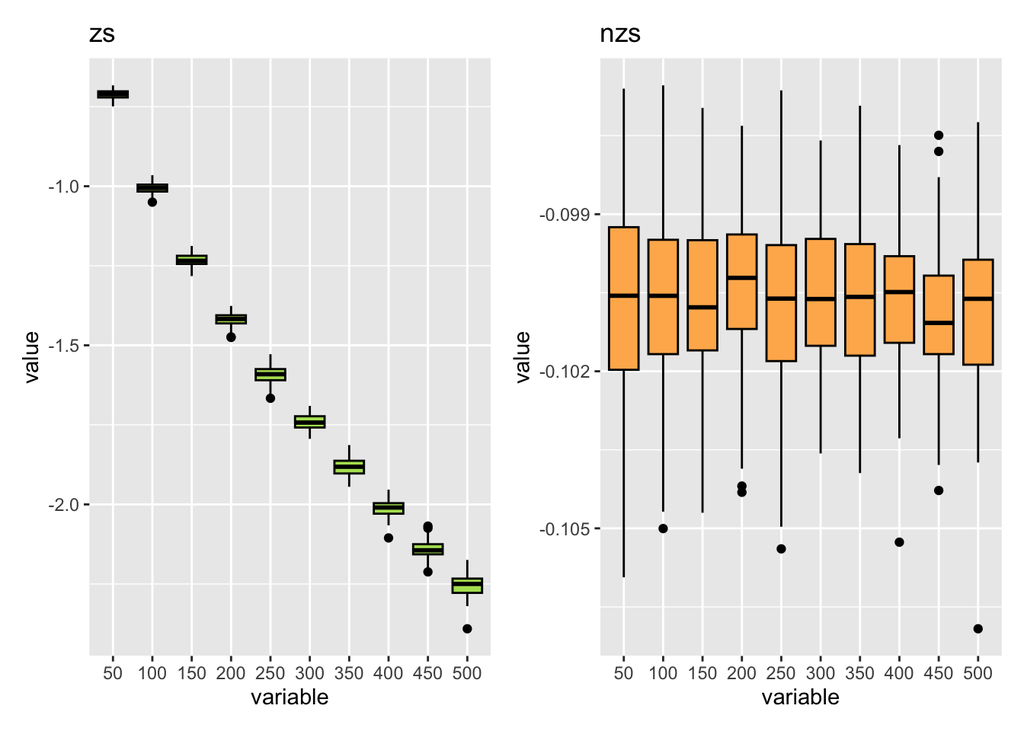